# Calculating Dissimilarity Metrics Across Space and Time COURSE SCALE BY BASIN

- This project is a collaborative effort to describe changes in taxonomic composition of fish communities around the world–as sampled by bottom trawl surveys.
- Code by Zoë J. Kitchel

```r
library(data.table)
library(vegan)
library(sf)
library(concaveman) #polygon around points
library(betapart) #allows us to partition beta diversity
library(geosphere)
library(ggpubr) #stat_regline_equation
library(nlme)


FishGlob_clean <- readRDS(here::here("data", "cleaned", "FishGlob.wellsampledyearscells_complete.final.rds"))
```

Are any survey_units missing CPUE?

```r
View(FishGlob_clean[, .(sum(is.na(wgt_cpue)),.N,(round(sum(is.na(wgt_cpue))/.N*100,1))), survey_unit])
```

Survey Season: NAs for wgt_cpue MEDITS: 350911 (no weights, only abundances, use abundances (num_cpue) instead?)

Otherwise, very small proportions, so will just exclude these observations.

Delete these observations above except for MEDITS (we will do trends in abundance metrics for this region)

```r
#delete all rows where wgt_cpue is NA,  unless it is MEDITS region
FishGlob_clean.noNA <- FishGlob_clean[(survey != "MEDITS" & !is.na(wgt_cpue)) | survey == "MEDITS"]

#check
summary(FishGlob_clean.noNA[, wgt_cpue]) #why inf? 13 observations from GSL-N,  I will delete these
```

```
   Min. 1st Qu.  Median    Mean 3rd Qu.    Max.    NA's
    0.0     3.9    24.1     Inf   151.8     Inf  350911
```

```r
FishGlob_clean.noNA <- copy(FishGlob_clean.noNA)[!is.infinite(wgt_cpue), ]
```

Loop through all regions (takes 6+ hours to run)

```r
all_survey_units <- unique(FishGlob_clean.noNA[, survey_unit])
```

For NZ-CHAT, we want to lump December observations with next year of observations (January, February)

```r
FishGlob_clean.noNA[survey_unit == "NZ-CHAT" & month == 12,  year := year+1, ]
```

Quick data set characteristics

```r
#number of hauls
nrow(unique(FishGlob_clean.noNA[,.(haul_id)]))
```

```
[1] 218172
```

```r
nrow(unique(FishGlob_clean.noNA[,.(accepted_name)]))
```

```
[1] 2044
```

```r
sort(unique(FishGlob_clean.noNA$year))
```

[output not shown]

Some spp are duplicated within a haul. In all cases, this is due to verbatim names matching to a single accepted name. Therefore, we will sum these wgts and abundances

```r
FishGlob_clean.noNA[, wgt := sum(wgt,  na.rm = T), .(accepted_name,  haul_id)][,
                     wgt_h := sum(wgt_h,  na.rm = T), .(accepted_name,  haul_id)][,
                     wgt_cpue := sum(wgt_cpue,  na.rm = T), .(accepted_name,  haul_id)][,
                     num := sum(num,  na.rm = T), .(accepted_name,  haul_id)][,
                     num_h := sum(num_h,  na.rm = T), .(accepted_name,  haul_id)][,
                     num_cpue := sum(num_cpue,  na.rm = T), .(accepted_name,  haul_id)]

FishGlob_clean.noNA <- unique(FishGlob_clean.noNA[,.(survey, haul_id, country, sub_area, continent, stat_rec, station, stratum, year, month, day, quarter, season, latitude, longitude, haul_dur, area_swept, gear, depth, sbt, sst, num, num_h, num_cpue, wgt, wgt_h, wgt_cpue, verbatim_aphia_id, accepted_name, aphia_id, SpecCode, kingdom, phylum, class, order, family, genus, rank, survey_unit, years_sampled, cell_ID, cell_year_count, year_cell_count, years_sampled_update)])
```

Link in pacific vs atlantic

```r
basin_helper <- data.table(basin = c("Pac",
                                    "Atl",
                                    "Atl",
                                    "Pac",
                                    "Atl",
                                    "Pac",
                                    "Pac",
                                    "Atl",
                                    "Atl",
                                    "Atl",
                                    "Pac",
                                    "Atl",
                                    "Atl",
                                    "Atl",
                                    "Atl",
                                    "Atl",
                                    "Atl",
                                    "Atl",
                                    "Atl",
                                    "Atl",
                                    "Atl",
                                    "Atl",
                                    "Atl",
                                    "Atl",
                                    "Atl",
                                    "Pac",
                                    "Pac",
                                    "Pac",
                                    "Atl",
                                    "Atl",
                                  "Atl",
                                  "Atl",
                                  "Atl",
                                  "Atl",
                                  "Pac",
                                  "Atl",
                                  "Ind",
                                   "Atl",
                                  "Atl",
                                  "Atl",
                                  "Atl",
                                  "Atl",
                                  "Atl",
                                  "Pac",
                                  "Atl"),
                          survey_unit = c(
                                  "AI",
                                  "BITS-1",
                                  "BITS-4",
                                  "CHL",
                                  "DFO-NF",
                                  "DFO-QCS",
                                  "EBS",
                                  "EVHOE",
                                  "FR-CGFS",
                                  "GMEX-Summer",
                                  "GOA",
                                  "GRL-DE",
                                  "GSL-N",
                                  "GSL-S",
                                  "ICE-GFS",
                                  "IE-IGFS",
                                  "MEDITS",
                                  "NAM",
                                  "NEUS-Fall",
                                  "NEUS-Spring",
                                  "NIGFS-1",
                                  "NIGFS-4",
                                  "Nor-BTS-3",
                                  "NS-IBTS-1",
                                  "NS-IBTS-3",
                                  "NZ-CHAT",
                                  "NZ-ECSI",
                                  "NZ-WCSI",
                                  "PT-IBTS",
                                  "S-GEORG",
                                  "SCS-SUMMER",
                                  "SEUS-fall",
                                  "SEUS-spring",
                                  "SEUS-summer",
                                  "WCANN",
                                  "ZAF-ATL",
                                  "ZAF-IND",
                                  "ROCKALL",
                                  "SWC-IBTS-1",
                                  "SWC-IBTS-4",
                                  "FALK",
                                  "GMEX-Fall",
                                  "Nor-BTS-1",
                                  "NZ-SUBA",
                                  "SCS-SPRING"
                          ))

merge
```

```
function (x, y, ...)
UseMethod("merge")
<bytecode: 0x7f972ce04490>
<environment: namespace:base>
```

```r
FishGlob_clean.noNA <- FishGlob_clean.noNA[basin_helper, on = "survey_unit"]

#exclude Indian ocean
FishGlob_clean.noNA <- FishGlob_clean.noNA[basin != "Ind"]
```

#Calculate annual cpue sums for each survey (probably across seasons once we figure out which years overlap)

```r
#add missing survey values
FishGlob_clean.noNA[survey_unit == "FALK",survey := "FALK"][survey_unit == "Nor-BTS-1",survey := "Nor-BTS"][survey_unit == "SCS-SPRING",survey := "SCS"]

FishGlob_clean.noNA[,wgt_cpue_year_survey_byspp := sum(wgt_cpue, na.rm = T),.(survey_unit,year,accepted_name)]

FishGlob_clean.noNA.u <- unique(FishGlob_clean.noNA[,.(survey_unit, year, wgt_cpue_year_survey_byspp, accepted_name, basin)])

#scale by region and species (relatively high or low amount for that species in that year, but do NOT scale because we can't calculate beta diversity on negative values)
FishGlob_clean.noNA.u[,wgt_cpue_year_survey_byspp.s := scale(wgt_cpue_year_survey_byspp, center = F),.(survey_unit, accepted_name)]
```

Plot year by whether we have data

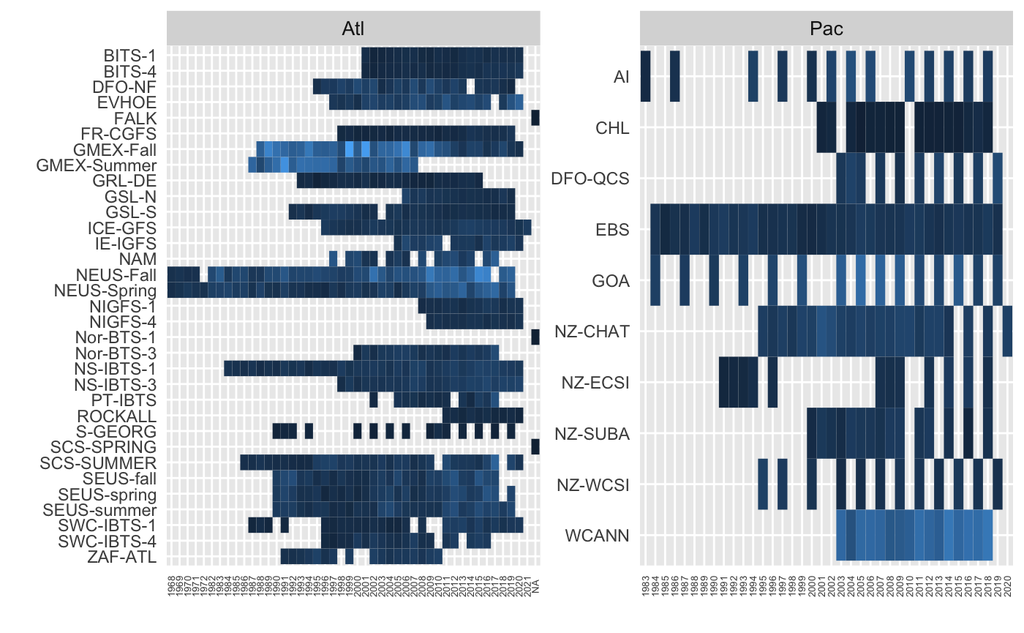

For Atlantic: